# Create Package using rrtools

Wolfgang Hamer

27 Juli, 2017

Abstract

This files recapitulates how to create a package using rrtools.

# 1 Introduction

Ben Marwick recommends the usuage of RStudio using his rrtools. As Daniel Knitter has shown in his [RRREmacs](http://htmlpreview.github.io/?https://github.com/dakni/EmacsEssay/blob/master/analysis/paper/paper.html) package, also Emacs can be the medium to use rrtools. Since I like to work with Tinn-R I tested rrtools using this environment.

# 2 First steps

At first I simply followed the steps explained in the rrtools readme file, beginning with the definition of my working directory and the installation of rrtools.

```r
setwd("E:/FilePath")

devtools::install_github("benmarwick/rrtools")
```

Then I went on creating the specific R package files with the rrtools and devtools methods.

```r
rrtools::use_compendium("TestOfBen")

devtools::use_mit_license(copyright_holder = "Wolfgang Hamer")

#Token:  https://github.com/settings/tokens
devtools::use_github(".", auth_token = "xxxxx", protocol = "https", private = FALSE)

rrtools::use_readme_rmd()

rrtools::use_analysis()

rrtools::use_dockerfile()

rrtools::use_travis()
```

At first the travis test would not pass, since the package name contained large letters:

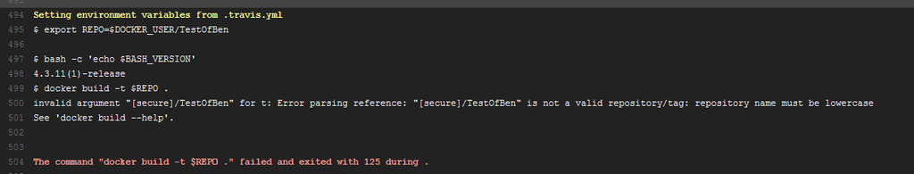

The problem could be solved quite easily by changing the entry in the travis.yml file:

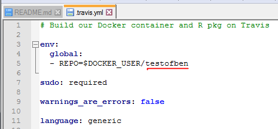

# 3 Build

Afterwards I could build the package and install it:

```r
devtools::build()

devtools::install()
```

Then I could render the .Rmd files:

```r
rmarkdown::render("analysis/paper/paper.Rmd")
```

and push the whole thing on my GitHub Account using the commands in the terminal:

- *git status*
- *git add .*
- *git commit -m “What was changed”*
- *git push*

### 3.0.1 Colophon

This report was generated on 2017-07-27 14:13:24 using the following computational environment and dependencies:

[output not shown]